# REN - One country over time, the case of Poland

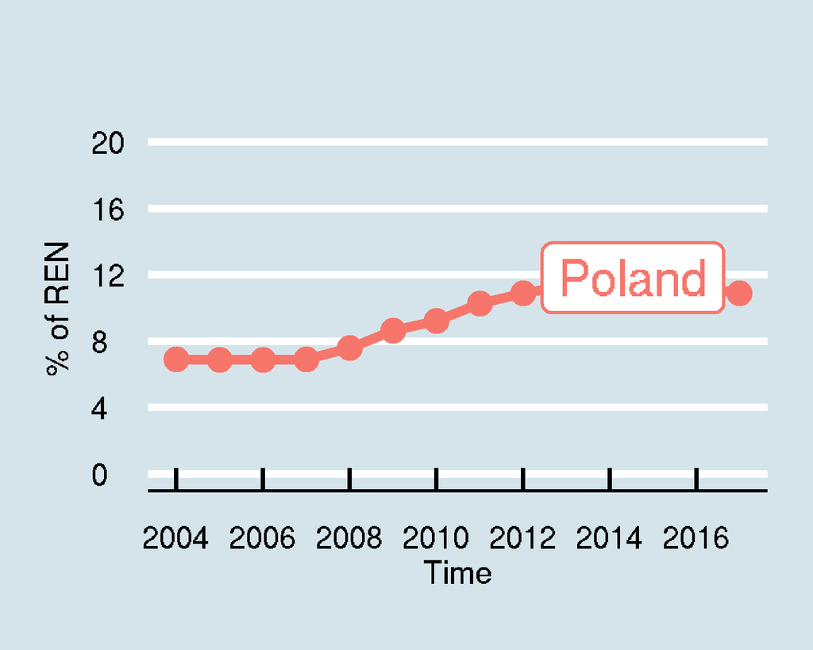

```r
sdg_07_40 %>%
  filter(nrg_bal == 'REN') %>%
  filter(geo %in% c('PL')) %>%
  mutate(lbl = if_else(time == max(time), as.character(Country), NA_character_)) %>%
  ggplot(aes(x = time, y = values, colour = geo)) +
  geom_line(size = 1) +
  geom_point(size = 2) +
  scale_x_continuous(breaks = seq(2004, 2018, by = 2)) +
  scale_y_continuous(limits = c(0, 20), breaks = seq(0, 20, by = 4)) +
  geom_label_repel(aes(label = lbl), nudge_x = 1, nudge_y = 0.5, na.rm = TRUE) +
  labs(x = "Time", y = "% of REN", title = "") +
  theme_economist() +
  theme(text = element_text(size = 7)) +
  theme(legend.position = "none")
```

# REN - Two countries over time, Greece + Poland

```r
sdg_07_40 %>%
  filter(nrg_bal == 'REN') %>%
  filter(geo %in% c('EL', 'PL')) %>%
  mutate(lbl = if_else(time == max(time), as.character(Country), NA_character_)) %>%
  ggplot(aes(x = time, y = values, colour = geo)) +
  geom_line(size = 1) +
  geom_point(size = 2) +
  scale_x_continuous(breaks = seq(2004, 2018, by = 2)) +
  scale_y_continuous(limits = c(0, 20), breaks = seq(0, 20, by = 4)) +
  geom_label_repel(aes(label = lbl), nudge_x = 1, nudge_y = 0.5, na.rm = TRUE) +
  labs(x = "Time", y = "% of REN", title = "") +
  theme_economist() +
  theme(text = element_text(size = 11)) +
  theme(legend.position = "none")
```

### SDMX

```r
filter(geo %in% c('EL', 'PL'))
```

- Adding a second value in the filtering vector is the only change in the code
- Data structure is the **same**

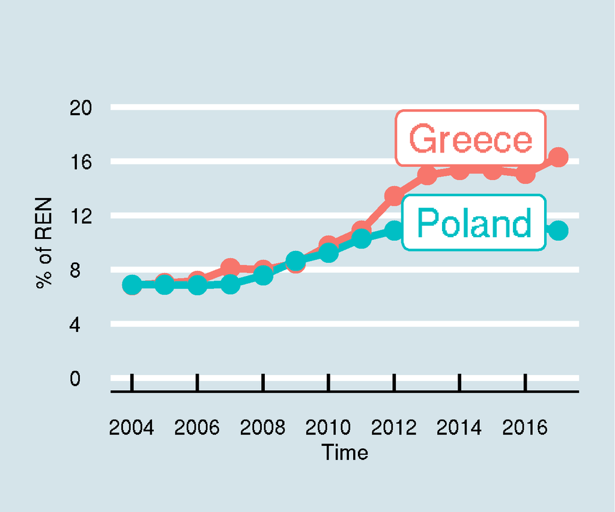

# REN - all countries

```r
sdg_07_40 %>%
  filter(nrg_bal == 'REN') %>%
  ggplot(aes(x = time, y = values)) +
  geom_point(size = 0.6, color = "blue") +
  scale_x_continuous(breaks = seq(2004, 2018, by = 2)) +
  scale_y_continuous(limits = c(0, 60), breaks = seq(0, 60, by = 10)) +
  labs(x = "Time", y = "% of REN", title = element_blank()) +
  theme_economist() +
  theme(text = element_text(size = 11)) +
  theme(legend.position = "none")
```

### SDMX

- Just remove the Coutry filter to have all Countries
- Scatter plots help us to see the distribution of values of different countries
- So, can we plot the distribution?
- And yes, Sweden is on the top

[figure not shown]

# REN distribution - 2017

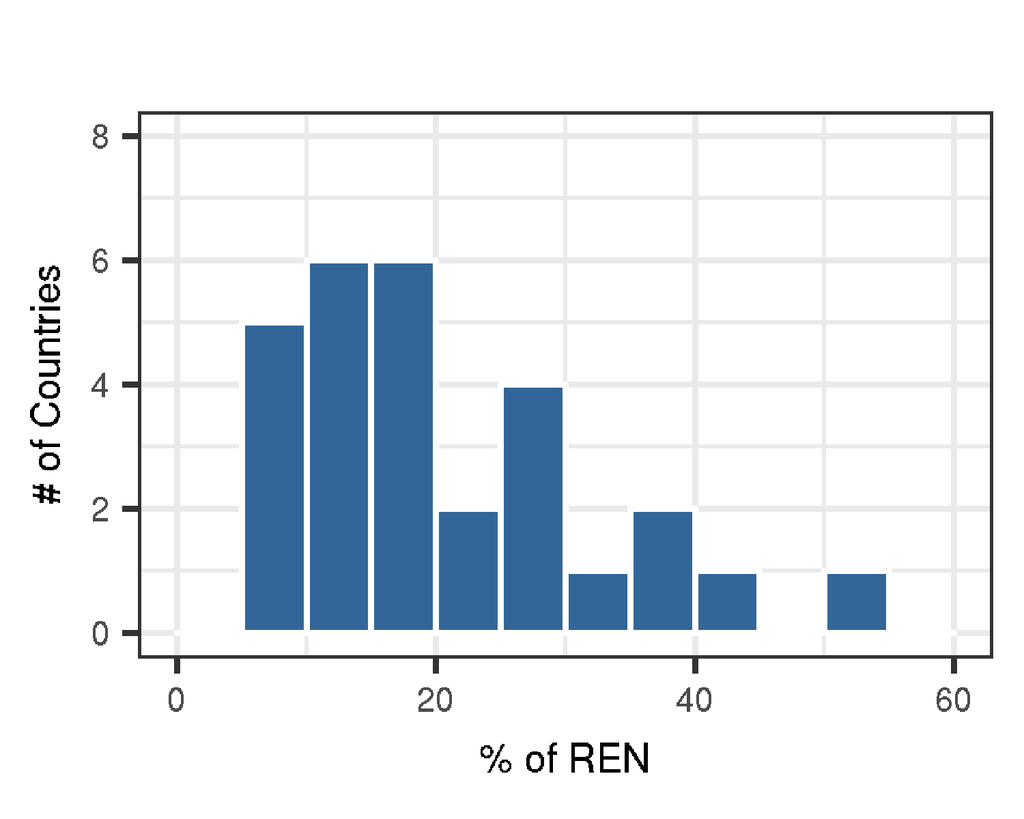

```r
sdg_07_40 %>%
  filter(nrg_bal == 'REN') %>%
  filter(time == 2017) %>%
  ggplot(aes(x = values)) +
  geom_histogram(breaks = seq(0, 60, by = 5), fill = "#336699", color = "white") +
  scale_y_continuous(limits = c(0, 8), breaks = seq(0, 8, by = 2)) +
  labs(x = "% of REN", y = "# of Countries", title = "") +
  theme_bw() +
  theme(text = element_text(size = 16)) +
  theme(legend.position = "none")
```

# REN distribution - all years

```r
sdg_07_40 %>%
  filter(nrg_bal == 'REN') %>%
  ggplot(aes(x = values)) +
  geom_histogram(breaks = seq(0, 60, by = 5), fill = "#336699", color = "white") +
  scale_y_continuous(limits = c(0, 12), breaks = seq(0, 12, by = 2)) +
  labs(x = "% of REN", y = "# of Countries", title = "") +
  facet_wrap(~time) +
  theme_bw() +
  theme(text = element_text(size = 7)) +
  theme(legend.position = "none")
```

### SDMX

- no time filtering: all years
- just one line

[figure not shown]

# REN distribution - animation

```r
sdg_07_40 %>%
  filter(nrg_bal == 'REN') %>%
  ggplot(aes(x = values)) +
  geom_histogram(breaks = seq(0, 60, by = 5), fill = "#336699", color = "white") +
  scale_y_continuous(limits = c(0, 12), breaks = seq(0, 12, by = 2)) +
  labs(x = "% of REN", y = "# of Countries", title = "") +
  facet_wrap(~time) +
  theme_bw() +
  theme(text = element_text(size = 11)) +
  theme(legend.position = "none")
```

### SDMX

- no time filtering: all years
- just one line

```r
transition_time(time)
```

[figure not shown]